# Association of Two Variables

Abel Isaias Gutierrez-Cruz

4/10/2021

## Exercise 4.1

A newspaper asks two of its staff to review the coffee quality at different trendy cafés. The coffee can be rated on a scale from 1 (miserable) to 10 (excellent). The results of the two coffee enthusiasts X and Y are as follows:

| Café i | xi | yi |
| --- | --- | --- |
| 1 | 3 | 6 |
| 2 | 8 | 7 |
| 3 | 7 | 10 |
| 4 | 9 | 8 |
| 5 | 5 | 4 |

### a. Calculate and interpret Spearman’s rank correlation coefficient.

```r
# r
data_exercise41 <- data.frame(cafe = 1:5, x = c(3, 8, 7, 9, 5), y = c(6, 7, 10, 8, 4))
cor(x = data_exercise41$x, y = data_exercise41$y, method = 'spearman')
```

```
## [1] 0.6
```

```python
# python
from scipy import stats
import pandas as pd
import numpy as np

data_exercise41 = pd.DataFrame({"cafe":np.arange(1, 6), "x":[3, 8, 7, 9, 5], "y":[6, 7, 10, 8,4]})
stats.spearmanr(data_exercise41[["x"]], data_exercise41[["y"]])
```

```
## SpearmanrResult(correlation=0.6, pvalue=0.28475697986529375)
```

Both of the participant’s rates seem to have a moderate ascendent tendency. It means that both of them think that the coffee have a good quality

### b. Does Spearman’s R differ depending on whether ranks are assigned in a decreasing or increasing order?

No, it don’t. It does not matter wheter we choose an ascending or descending order of the ranks, the value remains the same

### c. Suppose the coffee can only be rated as either good ($>5$) or bad ($\leq5$). Do the chances of a good rating differ between the two journalists?

```r
# r
data_exercise41[, 2:3] <- ifelse(data_exercise41[, 2:3] > 5, "Good", "Bad")
data_exercise41 <- data.frame("quality" = c(data_exercise41$x, data_exercise41$y),
                                              "enthusiast" = c(rep("x", 5), rep("y", 5)))
identity_m41 <- table(data_exercise41$quality, data_exercise41$enthusiast)
identity_m41
```

```
##
##        x y
##   Bad  2 1
##   Good 3 4
```

```r
(identity_m41[1, 1]*identity_m41[2, 2]) / (identity_m41[1, 2]*identity_m41[2, 1])
```

```
## [1] 2.666667
```

```python
# python
data_exercise41['x'] = data_exercise41['x'].apply(lambda x: 1 if x > 5 else 0)
data_exercise41['y'] = data_exercise41['y'].apply(lambda x: 1 if x > 5 else 0)

contingency_data = pd.DataFrame({"quality": np.concatenate((data_exercise41['x'], data_exercise41['y'])), "enthusiast":np.concatenate((np.repeat("x", 5), np.repeat("y", 5)))})

contingency_data = pd.crosstab(contingency_data['quality'], contingency_data['enthusiast'], margins = False)
contingency_data
```

```
## enthusiast  x  y
## quality
## 0           2  1
## 1           3  4
```

```python
(contingency_data.iloc[0, 0] * contingency_data.iloc[1, 1])/(contingency_data.iloc[0, 1] * contingency_data.iloc[1, 0])
```

```
## 2.6666666666666665
```

## Exercise 4.2

A total of 150 customers of a petrol station are asked about their satisfaction with their car and motorbike insurance. The results are summarized below:

| . | Satisfied | Unsatisfied | Total |
| --- | --- | --- | --- |
| Car | 33 | 25 | 58 |
| Car (diesel engine) | 29 | 31 | 60 |
| Motorbike | 12 | 20 | 32 |
| Total | 74 | 76 | 150 |

### a. Determine and interpret Pearson’s $\chi^2$ statistic, Cramer’s $V$ , and $C_{corr}$.

```r
# r
data_exercise42 <- data.frame(Satisfied = c(33, 29, 12), Unsatisfied = c(25, 31, 20),
                              row.names =  c("Car", "Car (diesel engine)", "Motorbike"))

# ----- chi squared
chisq.test(data_exercise42)$expected
```

```
##                     Satisfied Unsatisfied
## Car                  28.61333    29.38667
## Car (diesel engine)  29.60000    30.40000
## Motorbike            15.78667    16.21333
```

```r
chisq_test_42 <- chisq.test(data_exercise42)$statistic
chisq_test_42
```

```
## X-squared
##  3.144007
```

```r
# ---- Cramers V
sqrt((chisq_test_42/150*(2-1)))
```

```
## X-squared
## 0.1447759
```

```r
# ---- Contingency Coefficient C
sqrt((2)/(2-1))*sqrt((chisq_test_42)/(chisq_test_42 + 150))
```

```
## X-squared
## 0.2026314
```

```python
# python
data_exercise42 = pd.DataFrame({"Satisfied": [33, 29, 12], "Unsatisfied": [25, 31, 20]},
                    index = ["Car", "Car (diesel engine)", "Motorbike"])

# ---- Chi squared
xsquare, pvalue, degreeF, expected = stats.chi2_contingency(data_exercise42)
xsquare

# ---- Cramers V
```

```
## 3.144007210477264
```

```python
np.sqrt(xsquare/150*(2-1))

# ----- Contingency Coefficient C
```

```
## 0.14477585458165468
```

```python
np.sqrt((2)/(2-1))*np.sqrt((xsquare/(xsquare + 150)))
```

```
## 0.20263140751600123
```

### b. Combine the categories “car” and “car (diesel engine)” and produce the corresponding 2 × 2 table. Calculate χ2 as efficiently as possible and give a meaningful interpretation of the odds ratio.

```r
# -------------------- r---------------------------
data_exercise42 <- rbind(data_exercise42[-c(1,2), ], data_exercise42[1, ] + data_exercise42[2, ])
data_exercise42 <- data_exercise42[2:1, ]

chisq.test(data_exercise42)$expected
```

```
##           Satisfied Unsatisfied
## Car        58.21333    59.78667
## Motorbike  15.78667    16.21333
```

```r
chisq.test(data_exercise42)$statistic
```

```
## X-squared
##  1.716753
```

```r
(data_exercise42[1, 1]*data_exercise42[2, 2]) / (data_exercise42[1, 2]*data_exercise42[2, 1])
```

```
## [1] 1.845238
```

```python
# -------------------- python ---------------------------
data_exercise42= data_exercise42.append(data_exercise42.loc[["Car", "Car (diesel engine)"]].sum(axis = 0),
                                                ignore_index = True).iloc[[3, 2]]
data_exercise42.rename(index = {3:"Car", 2:"Motorbike"})
```

```
##            Satisfied  Unsatisfied
## Car               62           56
## Motorbike         12           20
```

```python
xsquare, pvalue, degreeF, expected = stats.chi2_contingency(data_exercise42)
xsquare
```

```
## 1.7167529406357742
```

```python
(data_exercise42.iloc[0, 0] * data_exercise42.iloc[1, 1])/(data_exercise42.iloc[0, 1] * data_exercise42.iloc[1, 0])
```

```
## 1.8452380952380953
```

The chances of be satisfied are 1.84 times higher for individuals with car compared with individual with motorbike

### c. Compare the results from (a) and (b).

In both of the results, the association between the two variables is weak. Although, when we combined the categories “Car” and “Car (diesel engine)” the association was lower. The odds ratio give us a clear interpretation, but we should determinate if this is trustworthy

## Exercise 4.3

There has been a big debate about the usefulness of speed limits on public roads. Consider the following table which lists the speed limits for country roads (in miles/h) and traffic deaths (per 100 million km) for different countries in 1986 when the debate was particularly serious:

| Country | Speed limit | Traffic deaths |
| --- | --- | --- |
| Denmark | 55 | 4.1 |
| Japan | 55 | 4.7 |
| Canada | 60 | 4.3 |
| Netherlands | 60 | 5.1 |
| Italy | 75 | 6.1 |

#### a. Draw the scatter plot for the two variables.

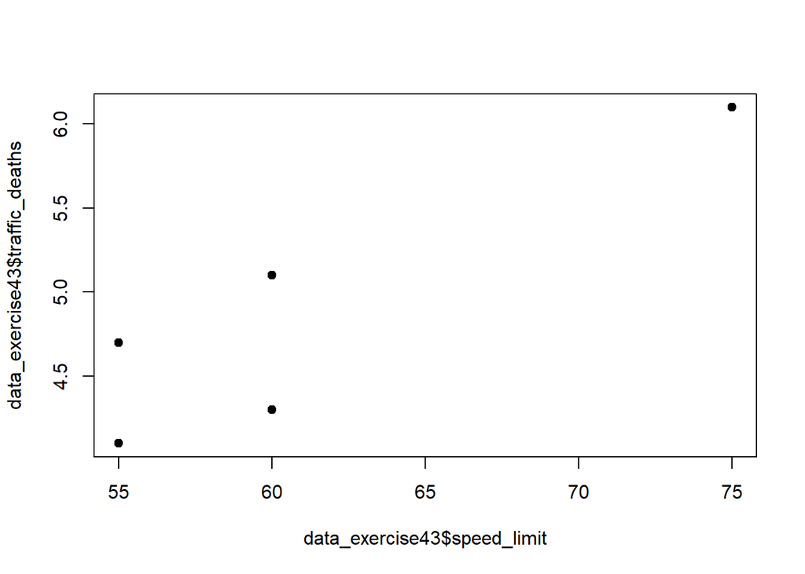

```r
# --------------------- r --------------------------------
data_exercise43 <- data.frame(country = c("Denmark", "Japan", "Canada", "Netherlands", "Italy"),
                              speed_limit = c(55, 55, 60, 60, 75),
                              traffic_deaths = c(4.1, 4.7, 4.3, 5.1, 6.1))

plot(data_exercise43$speed_limit, data_exercise43$traffic_deaths, pch= 19)
```

[figure not shown]

```python
# --------------------- python --------------------------------
import matplotlib.pyplot as plt

data_exercise43 = pd.DataFrame({"country": ["Denmark", "Japan", "Canada", "Netherlands", "Italy"],
                                "speed_limit": [55, 55, 60, 60, 75],
                                "traffic_deaths": [4.1, 4.7, 4.3, 5.1, 6.1]})

plt.plot(data_exercise43["speed_limit"], data_exercise43["traffic_deaths"])
plt.show()
```

#### b. Calculate the Bravais–Pearson and Spearman correlation coefficients.

```r
# --------------------- r --------------------------------
# Bravais-Pearson Correlation coefficient
cor(data_exercise43$speed_limit, data_exercise43$traffic_deaths, method = 'pearson')
```

```
## [1] 0.890833
```

```r
# Spearman correlation coefficients
cor(data_exercise43$speed_limit, data_exercise43$traffic_deaths, method = 'spearman')
```

```
## [1] 0.7378648
```

```python
# --------------------- python --------------------------------
# Bravais-Pearson Correlation coefficient
stats.pearsonr(data_exercise43["speed_limit"], data_exercise43["traffic_deaths"])

# Spearman correlation coefficients
```

```
## (0.8908329766625767, 0.042582247398142)
```

```python
stats.spearmanr(data_exercise43["speed_limit"], data_exercise43["traffic_deaths"])
```

```
## SpearmanrResult(correlation=0.7378647873726218, pvalue=0.15461852312844906)
```

#### c. What are the effects on the correlation coefficients if the speed limit is given in km/h rather than miles/h (1 mile/h $\approx$ 1.61 km/h)?

The results stay the same. These correlation coefficients are invariant from the units

#### d. Consider one more observation: the speed limit for England was 70 miles/h and the death rate was 3.1.

1. Add this observation to the scatter plot.

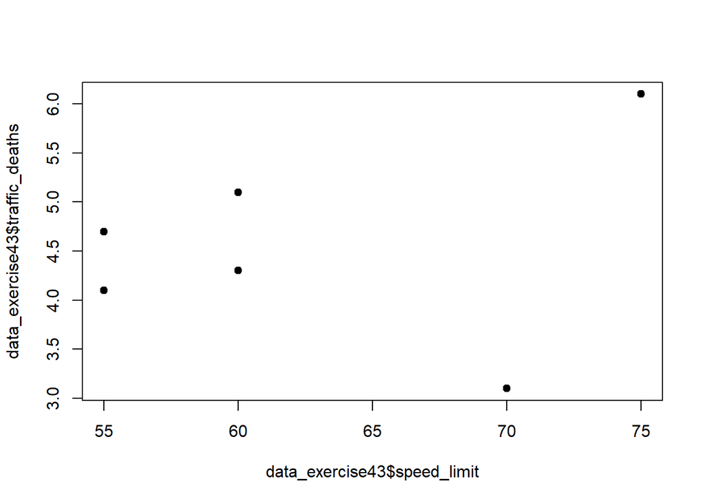

```r
# --------------------- r --------------------------------
data_exercise43 <- data_exercise43 <- rbind(data_exercise43, list("England", 70, 3.1))

plot(data_exercise43$speed_limit, data_exercise43$traffic_deaths, pch= 19)
```

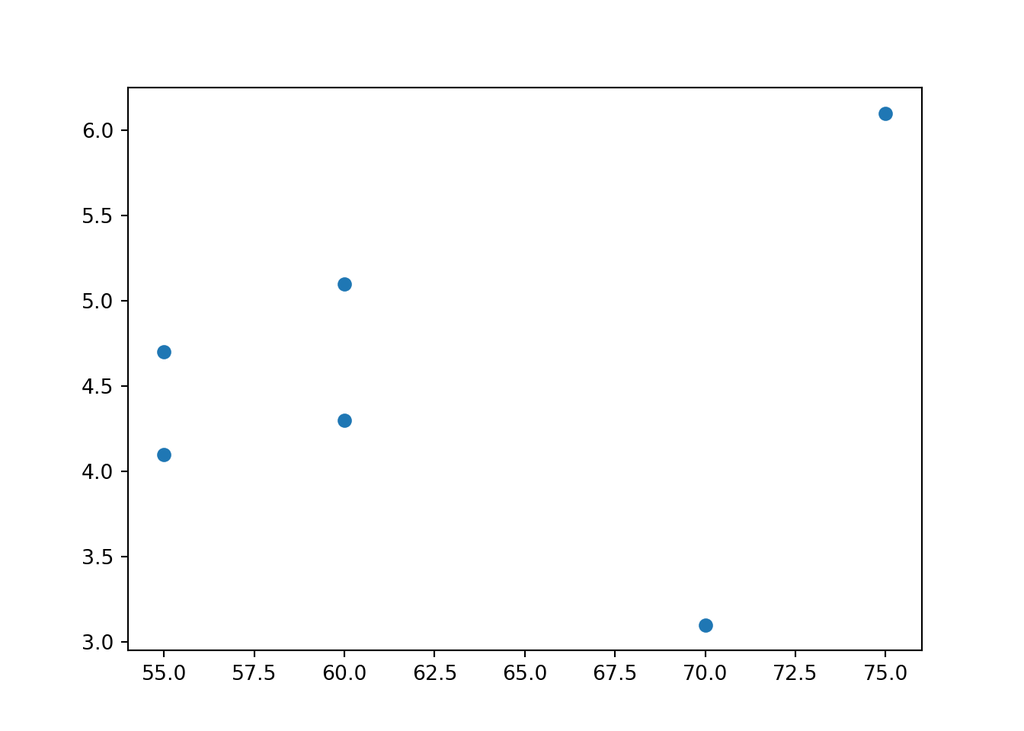

```python
# --------------------- python --------------------------------
data_exercise43.loc[5] = ["England", 70, 3.1]

plt.scatter(data_exercise43["speed_limit"], data_exercise43["traffic_deaths"])
plt.show()
```

2. Calculate the Bravais–Pearson correlation coefficient given this additional observation.

```r
# --------------------- r --------------------------------
# Bravais-Pearson Correlation coefficient
cor(data_exercise43$speed_limit, data_exercise43$traffic_deaths, method = 'pearson')
```

```
## [1] 0.2411915
```

```python
# --------------------- python --------------------------------
# Bravais-Pearson Correlation coefficient
stats.pearsonr(data_exercise43["speed_limit"], data_exercise43["traffic_deaths"])
```

```
## (0.24119153509747393, 0.6452281579441752)
```

When we added the last point to the dataframe, this modifies the linear relation between the two variables due to that value is low.

## Exercise 4.4

The famous passenger liner Titanic hit an iceberg in 1912 and sank. A total of 337 passengers travelled in first class, 285 in second class, and 721 in third class. In addition, there were 885 staff members on board. Not all passengers could be rescued. Only the following were rescued: 135 from the first class, 160 from the second class, 541 from the third class and 674 staff.

#### a. Determine and interpret the contingency table for the variables “travel class” and “rescue status”.

```r
# --------------------- r --------------------------------
data_exercise44 <- data.frame(first_class = c(135, 202, 337), second_class = c(160, 125, 285),
                              third_class = c(541, 180, 721), staff = c(674, 211, 885),
                              total = c(1510, 718, 2228),
                              row.names = c("Rescued", "NotRescued", "Total"))

kable(data_exercise44)
```

|  | first_class | second_class | third_class | staff | total |
| --- | --- | --- | --- | --- | --- |
| Rescued | 135 | 160 | 541 | 674 | 1510 |
| NotRescued | 202 | 125 | 180 | 211 | 718 |
| Total | 337 | 285 | 721 | 885 | 2228 |

```python
# --------------------- python --------------------------------
data_exercise44 = pd.DataFrame({"first_class": [135, 202, 337],
                                "second_class": [160, 125, 285],
                                "third_class": [541, 180, 721],
                                "staff": [674, 211, 885],
                                "Total": [1510, 718, 2228]},
                                index = ["Rescued", "NotRescued", "Total"])
data_exercise44
```

```
##             first_class  second_class  third_class  staff  Total
## Rescued             135           160          541    674   1510
## NotRescued          202           125          180    211    718
## Total               337           285          721    885   2228
```

#### b. Use a contingency table to summarize the conditional relative frequency distributions of rescue status given travel class. Could there be an association of the two variables?

```r
# --------------------- r --------------------------------
rela_freq_dist <- apply(data_exercise44[1:2, c(1, 2, 3, 4)], 1, function(xi, y){
    xi / y
}, y = data_exercise44[3, c(1, 2, 3, 4)])
rela_freq_dist <- rbind(rescued = rela_freq_dist$Rescued, not_resquet = rela_freq_dist$NotRescued)
kable(rela_freq_dist)
```

|  | first_class | second_class | third_class | staff |
| --- | --- | --- | --- | --- |
| rescued | 0.4005935 | 0.5614035 | 0.7503467 | 0.7615819 |
| not_resquet | 0.5994065 | 0.4385965 | 0.2496533 | 0.2384181 |

```python
# --------------------- python --------------------------------
data_exercise44.iloc[0:2, 0:4] / data_exercise44.iloc[2, 0:4]
```

```
##             first_class  second_class  third_class     staff
## Rescued        0.400593      0.561404     0.750347  0.761582
## NotRescued     0.599407      0.438596     0.249653  0.238418
```

If we determine the conditional frequency distribution of the rescue status given the travel class, we could see that there were fewer individuals rescued in the first classes. It could be due to the numbers of passengers in each class, for example, there were more individuals in the staff than in the first class.

#### c. What would the contingency table from (a) look like under the independence assumption? Calculate Cramer’s V statistic. Is there any association between travel class and rescue status?

```r
# ----- Expected values under independence
chisq.test(data_exercise44[1:2, 1:4])$expected
```

```
##            first_class second_class third_class   staff
## Rescued       228.3977     193.1553     488.649 599.798
## NotRescued    108.6023      91.8447     232.351 285.202
```

```r
# -------- Cramer Statistic -------
chisq_test_44 <- chisq.test(data_exercise44[1:2, 1:4])$statistic

sqrt((chisq_test_44/2228*(2-1)))
```

```
## X-squared
##   0.28586
```

```python
# --------------------- python --------------------------------
xsquare, pvalue, degreeF, expected = stats.chi2_contingency(data_exercise44.iloc[0:2, 0:4])

# ----- Expected values under independence
expected

# -------- Cramer Statistic -------
```

```
## array([[228.39766607, 193.15529623, 488.64901257, 599.79802513],
##        [108.60233393,  91.84470377, 232.35098743, 285.20197487]])
```

```python
np.sqrt(xsquare/2228*(2-1))
```

```
## 0.2858600473096204
```

If we consider the Cramer’s V statistic, there are a wear relation between the travel class and rescue status

#### d. Combine the categories “first class” and “second class” as well as “third class” and “staff”. Create a contingency table based on these new categories. Determine and interpret Cramer’s V , the odds ratio, and relative risks of your choice.

```r
# -------------------- r---------------------------
data_exercise44 <- cbind(first_second = data_exercise44[1:2, 1] + data_exercise44[1:2, 2],
                         third_staff = data_exercise44[1:2, 3] + data_exercise44[1:2, 4])
row.names(data_exercise44) <- c("Rescued", "NotRescued")

kable(data_exercise44)
```

|  | first_second | third_staff |
| --- | --- | --- |
| Rescued | 295 | 1215 |
| NotRescued | 327 | 391 |

```r
# ----- Cramer's V statistic
chisq.test(data_exercise44)$expected
```

```
##            first_second third_staff
## Rescued         421.553    1088.447
## NotRescued      200.447     517.553
```

```r
chisq_test_44 <- chisq.test(data_exercise44)$statistic

sqrt((chisq_test_44/2228*(2-1)))
```

```
## X-squared
## 0.2698669
```

```r
# ------- Odds ratio -------
(data_exercise44[1, 1]*data_exercise44[2, 2]) / (data_exercise44[1, 2]*data_exercise44[2, 1])
```

```
## [1] 0.2903185
```

```r
# Relative risk of Rescued given the travel class
(data_exercise44[1, 1]/(data_exercise44[1, 1] + data_exercise44[2, 1])) /
    (data_exercise44[1, 2]/(data_exercise44[1, 2] + data_exercise44[2, 2]))
```

```
## [1] 0.6269038
```

```python
# --------------------- python --------------------------------
data_exercise44["first_second"] = data_exercise44.iloc[0:3, 0:2].sum(axis = 1)
data_exercise44["third_staff"] = data_exercise44.iloc[0:3, 2:4].sum(axis = 1)

data_exercise44 = data_exercise44.iloc[0:2, 5:7]

# ----- Cramer's V statistic
xsquare, pvalue, degreeF, expected = stats.chi2_contingency(data_exercise44.iloc[0:2, 0:2])
np.sqrt(xsquare/2228*(2-1))

# ------- Odds ratio -------
```

```
## 0.2698668775531025
```

```python
(data_exercise44.iloc[0, 0] * data_exercise44.iloc[1, 1])/(data_exercise44.iloc[0, 1] * data_exercise44.iloc[1, 0])
```

```
## 0.2903185210354765
```

## Exercise 4.5

To study the association of the monthly average temperature (in °C, X) and hotel occupation (in $\%$, Y), we consider data from three cities: Polenca (Mallorca, Spain) as a summer holiday destination, Davos (Switzerland) as a winter skiing destination, and Basel (Switzerland) as a business destination

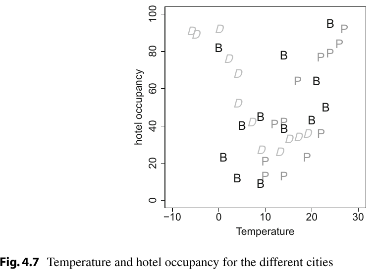

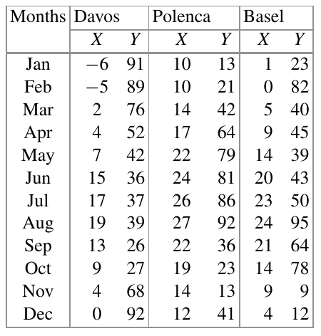

```r
Sxy <- 22776 - 36*(12.22*51.28)
Sxx <- 76.95*36
Syy <- 706.98*36
Sxy/sqrt(Sxx*Syy)
```

```
## [1] 0.02583176
```

If we consider this correlation coefficient, we could say that there is not a relation between both variables

```r
# --------------------- r --------------------------------
data_exercise45 <- data.frame(Months = rep(c("Jan", "Feb", "Mar",
                                                "Apr", "May", "Jun", "Jul", "Aug",
                                                "Sep", "Oct", "Nov", "Dec"), 3),
                              X = c(-6, -5, 2, 4, 7, 15, 17, 19, 13, 9, 4, 0, 10, 10,
                                    14, 17, 22, 24, 26, 27, 22, 19, 14, 12, 1, 0,
                                    5, 9, 14, 20, 23, 24, 21, 14, 9, 4),
                              Y = c(91, 89, 76, 52, 42, 36, 37, 39, 26, 27, 68, 92,
                                    13, 21, 42, 64, 79, 81, 86, 92, 36, 23, 12, 41,
                                    23, 82, 40, 45, 39, 43, 50, 95, 64, 78, 9, 12),
                              City = c(rep("Davos", 12), rep("Polenca", 12), rep("Basel", 12)))


data_exercise45 %>% group_by(City) %>% summarize(cor(X, Y, method = "pearson"))
```

```
## # A tibble: 3 x 2
##   City    `cor(X, Y, method = "pearson")`
##   <chr>                             <dbl>
## 1 Basel                             0.415
## 2 Davos                            -0.870
## 3 Polenca                           0.817
```

```python
# --------------------- python --------------------------------
data_exercise45 = pd.DataFrame({"Months": np.repeat([["Jan", "Feb", "Mar",
                                                "Apr", "May", "Jun", "Jul", "Aug",
                                                "Sep", "Oct", "Nov", "Dec"]], 3, 0).reshape((36, )),
                                "X":[-6, -5, 2, 4, 7, 15, 17, 19, 13, 9, 4, 0, 10, 10,
                                    14, 17, 22, 24, 26, 27, 22, 19, 14, 12, 1, 0,
                                    5, 9, 14, 20, 23, 24, 21, 14, 9, 4],
                                "Y": [91, 89, 76, 52, 42, 36, 37, 39, 26, 27, 68, 92,
                                    13, 21, 42, 64, 79, 81, 86, 92, 36, 23, 12, 41,
                                    23, 82, 40, 45, 39, 43, 50, 95, 64, 78, 9, 12],
                                "City": np.repeat(["Davos", "Polenca", "Basel"], 12)})
```

```python
data_exercise45.pipe(lambda x: x.groupby("City")).apply(lambda x: (stats.pearsonr(x.X, x.Y)))
```

```
## City
## Basel         (0.41517275443458035, 0.17956333049000187)
## Davos      (-0.8704197408898524, 0.00023055191669307392)
## Polenca      (0.8172671932515481, 0.0011702302941546472)
## dtype: object
```

## Exercise 4.6

Consider a neighbourhood survey on the use of a local park. Respondents were asked whether the park may be used for summer music concerts and whether dog owners should put their dogs on a lead. The results are summarized in the following contingency table:

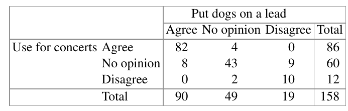

```r
# --------------------- r --------------------------------
data_exercise46 <- data.frame(dog_agree = c(82, 8, 0, 90), dog_no_opinion = c(4, 43, 2, 49),
                              dog_disagre = c(0, 9, 10, 19), dog_total = c(86, 60, 12, 158),
                              row.names = c("con_agree", "con_no_opinion", "con_disagree", "con_total"))
```

```python
# --------------------- python --------------------------------
data_exercise46 = pd.DataFrame({"dog_agree": [82, 8, 0, 90], "dog_no_opinion":[4, 43, 2, 49],
                                "dog_disagree": [0, 9, 10, 19], "dog_total":[86, 60, 12, 158]},
                                index = ["con_agree", "con_no_opinion", "con_disagree", "con_total"])
```

#### a) Calculate and interpret Goodman and Kruskal’s $\gamma$.

```r
library(ryouready)
ord.gamma(as.matrix(data_exercise46[1:3, 1:3]))
```

```
## Goodman-Kruskal Gamma: 0.983
```

#### b) Create the contingency table which is obtained when the categories “no opinion” and “agree” are combined.

```r
# --------------------- r --------------------------------
data_exercise46 <- rbind(data_exercise46[-c(1,2), ], con_agree_onot = data_exercise46[1, ] + data_exercise46[2, ])
data_exercise46 <- cbind(data_exercise46[, c(3, 4)], dog_agree_onot = data_exercise46[, 1] + data_exercise46[, 2])

data_exercise46 <- data_exercise46[c(3, 1, 2), c(3, 1, 2)]
```

```python
# --------------------- python --------------------------------
data_exercise46 =  data_exercise46.append(data_exercise46.iloc[0:2, 0:4].sum(axis = 0),
                                            ignore_index = True).iloc[[4, 2, 3]]
data_exercise46["dog_agree_onot"] = data_exercise46.iloc[0:3, 0:2].sum(axis = 1)

data_exercise46 = data_exercise46.iloc[:, [4, 2, 3]]
data_exercise46.rename(index = {4: "con_agree_onot", 2:"con_disagree", 3:"con_total"})
```

```
##                 dog_agree_onot  dog_disagree  dog_total
## con_agree_onot             137             9        146
## con_disagree                 2            10         12
## con_total                  139            19        158
```

#### c) What is the relative risk of disagreement with summer concerts depending on the opinion about using leads?

```r
(data_exercise46[2, 1]/data_exercise46[3, 1])/(data_exercise46[2, 2]/data_exercise46[3, 2])
```

```
## [1] 0.02733813
```

People who disagree with using the park for concerns are 0.03 times lower in the group of people who agree with the dogs owners should put their dogs on a lead than who disagree.

#### d) Calculate the odds ratio and offer two interpretations of it.

```r
(data_exercise46[1, 1]*data_exercise46[2, 2]) / (data_exercise46[1, 2]*data_exercise46[2, 1])
```

```
## [1] 76.11111
```

The chances of not disagreeing with using the park for concerns is 76 times higher for those who do not disagree with that the dogs owners should put their dogs on a lead.

#### e) Determine $\gamma$ for the table calculated in (c).

```r
library(ryouready)
ord.gamma(as.matrix(data_exercise46[1:2, 1:2]))
```

```
## Goodman-Kruskal Gamma: 0.974
```

#### f) What is your final interpretation and what may be the best measure to use in this example?

With the help of the Goodman and Kruskal’s $\gamma$, we could say that the agreement with both questions is strongly related, due to the value is high. Measures like the relative risks and odds ratios give us an interpretation easier to understand but we can not plenty rely on them.

## Exercise 4.7

Make yourself familiar with the Olympic decathlon data described in Appendix A.4. Read in and attach the data in R.

```r
data_exercise47 <- read.csv("../../Data/decathlon.csv", row.names = 1)
summary(data_exercise47)
```

```
##      X.100m       X.Long.jump      X.Shot.put     X.High.jump
##  Min.   :10.44   Min.   :6.610   Min.   :13.04   Min.   :1.850
##  1st Qu.:10.85   1st Qu.:7.000   1st Qu.:13.88   1st Qu.:1.917
##  Median :10.91   Median :7.260   Median :14.77   Median :1.940
##  Mean   :10.93   Mean   :7.249   Mean   :14.57   Mean   :1.973
##  3rd Qu.:11.08   3rd Qu.:7.478   3rd Qu.:15.15   3rd Qu.:2.030
##  Max.   :11.36   Max.   :7.960   Max.   :16.36   Max.   :2.150
##                                  NA's   :1
##      X.400m      X.110m.hurdle      X.Discus      X.Pole.vault
##  Min.   :46.81   Min.   :13.97   Min.   :38.19   Min.   :4.200
##  1st Qu.:49.00   1st Qu.:14.22   1st Qu.:41.19   1st Qu.:4.500
##  Median :49.37   Median :14.48   Median :44.07   Median :4.700
##  Mean   :49.67   Mean   :14.61   Mean   :44.02   Mean   :4.734
##  3rd Qu.:50.48   3rd Qu.:14.97   3rd Qu.:45.62   3rd Qu.:4.900
##  Max.   :53.20   Max.   :15.80   Max.   :51.65   Max.   :5.400
##                                                  NA's   :1
##    X.Javeline       X.1500m
##  Min.   :50.62   Min.   :263.1
##  1st Qu.:55.30   1st Qu.:270.0
##  Median :58.94   Median :276.0
##  Mean   :58.92   Mean   :276.9
##  3rd Qu.:61.22   3rd Qu.:279.7
##  Max.   :70.52   Max.   :317.0
##
```

```r
head(data_exercise47, 5)
```

```
##                X.100m X.Long.jump X.Shot.put X.High.jump X.400m X.110m.hurdle
## Roman Sebrle    10.85        7.84      16.36        2.12  48.36         14.05
## Bryan Clay      10.44        7.96      15.23        2.06  49.19         14.13
## Dmitriy Karpov  10.50        7.81      15.93        2.09  46.81         13.97
## Dean Macey      10.89        7.47      15.73        2.15  48.97         14.56
## Chiel Warners   10.62        7.74      14.48        1.97  47.97         14.01
##                X.Discus X.Pole.vault X.Javeline X.1500m
## Roman Sebrle      48.72          5.0      70.52  280.01
## Bryan Clay        50.11          4.9      69.71  282.00
## Dmitriy Karpov    51.65          4.6      55.54  278.11
## Dean Macey        48.34          4.4      58.46  265.42
## Chiel Warners     43.73          4.9      55.39  278.05
```

```r
str(data_exercise47)
```

```
## 'data.frame':    30 obs. of  10 variables:
##  $ X.100m       : num  10.8 10.4 10.5 10.9 10.6 ...
##  $ X.Long.jump  : num  7.84 7.96 7.81 7.47 7.74 7.14 7.19 7.53 7.48 7.49 ...
##  $ X.Shot.put   : num  16.4 15.2 15.9 15.7 14.5 ...
##  $ X.High.jump  : num  2.12 2.06 2.09 2.15 1.97 2.12 2.03 1.88 2.12 1.94 ...
##  $ X.400m       : num  48.4 49.2 46.8 49 48 ...
##  $ X.110m.hurdle: num  14.1 14.1 14 14.6 14 ...
##  $ X.Discus     : num  48.7 50.1 51.6 48.3 43.7 ...
##  $ X.Pole.vault : num  5 4.9 4.6 4.4 4.9 4.7 4.8 5.4 4.4 5.1 ...
##  $ X.Javeline   : num  70.5 69.7 55.5 58.5 55.4 ...
##  $ X.1500m      : num  280 282 278 265 278 ...
```

```python
data_exercise47 = pd.read_csv("../../Data/decathlon.csv", encoding= 'unicode_escape', index_col = 0)
data_exercise47.head()
```

```
##                 X.100m  X.Long.jump  ...  X.Javeline  X.1500m
## Roman Sebrle     10.85         7.84  ...       70.52   280.01
## Bryan Clay       10.44         7.96  ...       69.71   282.00
## Dmitriy Karpov   10.50         7.81  ...       55.54   278.11
## Dean Macey       10.89         7.47  ...       58.46   265.42
## Chiel Warners    10.62         7.74  ...       55.39   278.05
##
## [5 rows x 10 columns]
```

```python
data_exercise47.info()
```

```
## <class 'pandas.core.frame.DataFrame'>
## Index: 30 entries, Roman Sebrle to Victor Covalenco
## Data columns (total 10 columns):
##  #   Column         Non-Null Count  Dtype
## ---  ------         --------------  -----
##  0   X.100m         30 non-null     float64
##  1   X.Long.jump    30 non-null     float64
##  2   X.Shot.put     29 non-null     float64
##  3   X.High.jump    30 non-null     float64
##  4   X.400m         30 non-null     float64
##  5   X.110m.hurdle  30 non-null     float64
##  6   X.Discus       30 non-null     float64
##  7   X.Pole.vault   29 non-null     float64
##  8   X.Javeline     30 non-null     float64
##  9   X.1500m        30 non-null     float64
## dtypes: float64(10)
## memory usage: 2.6+ KB
```

```python
data_exercise47.describe()
```

```
##           X.100m  X.Long.jump  X.Shot.put  ...  X.Pole.vault  X.Javeline     X.1500m
## count  30.000000    30.000000   29.000000  ...     29.000000   30.000000   30.000000
## mean   10.930333     7.249333   14.570345  ...      4.734483   58.921667  276.900667
## std     0.232890     0.338332    0.890820  ...      0.284449    4.984182   11.249946
## min    10.440000     6.610000   13.040000  ...      4.200000   50.620000  263.080000
## 25%    10.850000     7.000000   13.880000  ...      4.500000   55.300000  270.030000
## 50%    10.915000     7.260000   14.770000  ...      4.700000   58.940000  276.010000
## 75%    11.080000     7.477500   15.150000  ...      4.900000   61.220000  279.712500
## max    11.360000     7.960000   16.360000  ...      5.400000   70.520000  317.000000
##
## [8 rows x 10 columns]
```

1. Use R to calculate and interpret the Bravais–Pearson correlation coefficient between the results of the discus and the shot-put events.

```r
# --------------------- r --------------------------------
good <- complete.cases(data_exercise47)
data_exercise47 <- data_exercise47[good, ]
cor(data_exercise47$X.Discus, data_exercise47$X.Shot.put, method = 'pearson')
```

```
## [1] 0.6657743
```

```python
# --------------------- python -------------------------------
data_exercise47 = data_exercise47.dropna(axis=0)
stats.pearsonr(data_exercise47["X.Discus"], data_exercise47["X.Shot.put"])
```

```
## (0.6657743455216862, 0.00011033166337561869)
```

There is a moderate relation between the variables.

2. There are 10 continuous variables. How many different correlation coefficients can you calculate? How would you summarize them? If we consider that the correlation coefficient considers two variables, there are 45 possible measurements. To show the correlation of each pair, we could make a correlation matrix:

```r
# --------------------- r --------------------------------
corr <- cor(data_exercise47, method = 'pearson')
corr
```

```
##                    X.100m X.Long.jump  X.Shot.put  X.High.jump      X.400m
## X.100m         1.00000000 -0.70496966 -0.36969566 -0.309283792  0.63478518
## X.Long.jump   -0.70496966  1.00000000  0.19545125  0.345662087 -0.67111115
## X.Shot.put    -0.36969566  0.19545125  1.00000000  0.612582295 -0.19930019
## X.High.jump   -0.30928379  0.34566209  0.61258229  1.000000000 -0.16915905
## X.400m         0.63478518 -0.67111115 -0.19930019 -0.169159053  1.00000000
## X.110m.hurdle  0.54255793 -0.53816329 -0.24506987 -0.325957691  0.51988045
## X.Discus      -0.23331691  0.24990923  0.66577435  0.516963291 -0.14418633
## X.Pole.vault  -0.26045206  0.28507937  0.02369214 -0.042382049 -0.11542821
## X.Javeline    -0.01168981  0.09379205  0.38334308  0.204481236 -0.05465387
## X.1500m        0.05843441 -0.14742605  0.12954382 -0.003496111  0.55122370
##               X.110m.hurdle   X.Discus X.Pole.vault  X.Javeline      X.1500m
## X.100m           0.54255793 -0.2333169  -0.26045206 -0.01168981  0.058434406
## X.Long.jump     -0.53816329  0.2499092   0.28507937  0.09379205 -0.147426053
## X.Shot.put      -0.24506987  0.6657743   0.02369214  0.38334308  0.129543822
## X.High.jump     -0.32595769  0.5169633  -0.04238205  0.20448124 -0.003496111
## X.400m           0.51988045 -0.1441863  -0.11542821 -0.05465387  0.551223700
## X.110m.hurdle    1.00000000 -0.2168722  -0.15097483 -0.07981966  0.179045379
## X.Discus        -0.21687217  1.0000000  -0.18421149  0.25485350  0.220171580
## X.Pole.vault    -0.15097483 -0.1842115   1.00000000 -0.06610479  0.179471438
## X.Javeline      -0.07981966  0.2548535  -0.06610479  1.00000000 -0.251505647
## X.1500m          0.17904538  0.2201716   0.17947144 -0.25150565  1.000000000
```

```python
# --------------------- python --------------------------------
corr = stats.spearmanr(data_exercise47)
corr
```

[output not shown]

## Exercise 4.8

We are interested in the pizza delivery data which is described in Appendix A.4.

```r
# --------------------- r --------------------------------
data_exercise48 <- read.csv("../../Data/pizza_delivery.csv")
summary(data_exercise48)
```

```
##      day                date                time         operator
##  Length:1266        Length:1266        Min.   :12.27   Length:1266
##  Class :character   Class :character   1st Qu.:30.06   Class :character
##  Mode  :character   Mode  :character   Median :34.38   Mode  :character
##                                        Mean   :34.23
##                                        3rd Qu.:38.58
##                                        Max.   :53.10
##     branch             driver           temperature         bill
##  Length:1266        Length:1266        Min.   :41.76   Min.   : 9.10
##  Class :character   Class :character   1st Qu.:58.24   1st Qu.:35.50
##  Mode  :character   Mode  :character   Median :62.93   Median :42.90
##                                        Mean   :62.86   Mean   :42.76
##                                        3rd Qu.:67.23   3rd Qu.:50.50
##                                        Max.   :87.58   Max.   :75.00
##      pizzas         free_wine         got_wine      discount_customer
##  Min.   : 1.000   Min.   :0.0000   Min.   :0.0000   Min.   :0.000
##  1st Qu.: 2.000   1st Qu.:0.0000   1st Qu.:0.0000   1st Qu.:0.000
##  Median : 3.000   Median :0.0000   Median :0.0000   Median :0.000
##  Mean   : 3.013   Mean   :0.1809   Mean   :0.1485   Mean   :0.218
##  3rd Qu.: 4.000   3rd Qu.:0.0000   3rd Qu.:0.0000   3rd Qu.:0.000
##  Max.   :11.000   Max.   :1.0000   Max.   :1.0000   Max.   :1.000
```

```r
head(data_exercise48, 5)
```

```
##        day      date     time operator branch    driver temperature bill pizzas
## 1 Thursday 01-May-14 35.12837    Laura   East     Bruno    68.28772 58.4      4
## 2 Thursday 01-May-14 25.20307  Melissa   East Salvatore    70.99779 26.4      2
## 3 Thursday 01-May-14 45.64340  Melissa   West Salvatore    53.39415 58.1      3
## 4 Thursday 01-May-14 29.37430  Melissa   East Salvatore    70.30660 35.2      3
## 5 Thursday 01-May-14 29.99461  Melissa   West Salvatore    71.50169 38.4      2
##   free_wine got_wine discount_customer
## 1         0        0                 1
## 2         0        0                 0
## 3         1        0                 0
## 4         0        0                 0
## 5         0        0                 0
```

```r
str(data_exercise48)
```

```
## 'data.frame':    1266 obs. of  12 variables:
##  $ day              : chr  "Thursday" "Thursday" "Thursday" "Thursday" ...
##  $ date             : chr  "01-May-14" "01-May-14" "01-May-14" "01-May-14" ...
##  $ time             : num  35.1 25.2 45.6 29.4 30 ...
##  $ operator         : chr  "Laura" "Melissa" "Melissa" "Melissa" ...
##  $ branch           : chr  "East" "East" "West" "East" ...
##  $ driver           : chr  "Bruno" "Salvatore" "Salvatore" "Salvatore" ...
##  $ temperature      : num  68.3 71 53.4 70.3 71.5 ...
##  $ bill             : num  58.4 26.4 58.1 35.2 38.4 61.8 57.9 35.8 36.6 44.8 ...
##  $ pizzas           : int  4 2 3 3 2 4 3 2 2 5 ...
##  $ free_wine        : int  0 0 1 0 0 1 1 0 0 0 ...
##  $ got_wine         : int  0 0 0 0 0 1 1 0 0 0 ...
##  $ discount_customer: int  1 0 0 0 0 0 0 0 0 0 ...
```

```python
# --------------------- python --------------------------------
data_exercise48 = pd.read_csv("../../Data/pizza_delivery.csv", encoding= 'unicode_escape')
data_exercise48.head()
```

```
##         day       date       time  ... free_wine got_wine discount_customer
## 0  Thursday  01-May-14  35.128367  ...         0        0                 1
## 1  Thursday  01-May-14  25.203074  ...         0        0                 0
## 2  Thursday  01-May-14  45.643404  ...         1        0                 0
## 3  Thursday  01-May-14  29.374297  ...         0        0                 0
## 4  Thursday  01-May-14  29.994610  ...         0        0                 0
##
## [5 rows x 12 columns]
```

```python
data_exercise48.info()
```

```
## <class 'pandas.core.frame.DataFrame'>
## RangeIndex: 1266 entries, 0 to 1265
## Data columns (total 12 columns):
##  #   Column             Non-Null Count  Dtype
## ---  ------             --------------  -----
##  0   day                1266 non-null   object
##  1   date               1266 non-null   object
##  2   time               1266 non-null   float64
##  3   operator           1266 non-null   object
##  4   branch             1266 non-null   object
##  5   driver             1266 non-null   object
##  6   temperature        1266 non-null   float64
##  7   bill               1266 non-null   float64
##  8   pizzas             1266 non-null   int64
##  9   free_wine          1266 non-null   int64
##  10  got_wine           1266 non-null   int64
##  11  discount_customer  1266 non-null   int64
## dtypes: float64(3), int64(4), object(5)
## memory usage: 118.8+ KB
```

```python
data_exercise48.describe()
```

```
##               time  temperature  ...     got_wine  discount_customer
## count  1266.000000  1266.000000  ...  1266.000000        1266.000000
## mean     34.229551    62.863950  ...     0.148499           0.218009
## std       6.461478     6.905708  ...     0.355735           0.413057
## min      12.266028    41.758718  ...     0.000000           0.000000
## 25%      30.061151    58.242364  ...     0.000000           0.000000
## 50%      34.381964    62.926657  ...     0.000000           0.000000
## 75%      38.577021    67.228628  ...     0.000000           0.000000
## max      53.096264    87.582422  ...     1.000000           1.000000
##
## [8 rows x 7 columns]
```

1. Read in the data and create two new binary variables which describe whether a pizza was hot ($>$ 65 °C) and the delivery time was short ($<$ 30 min). Create a contingency table for the two new variables.

```r
# --------------------- r --------------------------------
data_exercise48 <-  data_exercise48 %>%
                        mutate(temp_bin = ifelse(data_exercise48$temperature > 65,
                                                 "Hot", "NotHot"),
                               time_bin = ifelse(data_exercise48$time < 30, "Less30", "More30"))

contingency <- table(data_exercise48$temp_bin, data_exercise48$time_bin)
contingency
```

```
##
##          Less30 More30
##   Hot       213    261
##   NotHot    101    691
```

```python
# --------------------- python --------------------------------
data_exercise48["temp_bin"] = data_exercise48["temperature"].apply(lambda x: "Hot" if x > 65 else "NotHot")
data_exercise48["time_bin"] = data_exercise48["time"].apply(lambda x: "Less30" if x < 30 else "More30")

contingency = pd.crosstab(data_exercise48["temp_bin"], data_exercise48["time_bin"], margins = False)
contingency
```

```
## time_bin  Less30  More30
## temp_bin
## Hot          213     261
## NotHot       101     691
```

2. Calculate and interpret the odds ratio for the contingency table from (a).

```r
# --------------------- r --------------------------------
(contingency[1, 1]*contingency[2, 2]) / (contingency[1, 2]*contingency[2, 1])
```

```
## [1] 5.583362
```

The chances to have a cold pizza is 5 times higher if the delivery time is high

3. Use Cramer’s $V$ , Stuart’s $\tau_c$ , Goodman and Kruskal’s $\gamma$, and a stacked bar chart to explore the association between the categorical time and temperature variables.

```r
# ----- cramers V -----
chisq <- chisq.test(contingency)$statistic

sqrt((chisq/1266*(2-1)))
```

```
## X-squared
## 0.3587812
```

```r
# ---- stuart tau -----
library(ryouready)
ord.tau(contingency)
```

```
## Kendall's (and Stuart's) Tau statistics
##  Tau-b: 0.361
##  Tau-c: 0.302
```

```r
# ---- Goodman gamma -----
ord.gamma(contingency)
```

```
## Goodman-Kruskal Gamma: 0.696
```

This show that the variable have a moderate-to-weak relation between them.

4. Draw a scatter plot for the continuous time and temperature variables. Determine both the Bravais–Pearson and Spearman correlation coefficients.

```r
# ------ Brabais-Pearson -----
cor(data_exercise48$temperature, data_exercise48$time, method = 'pearson')
```

```
## [1] -0.433935
```

```r
# ------- Spearman ---------
cor(data_exercise48$temperature, data_exercise48$time, method = 'spearman')
```

```
## [1] -0.3912803
```

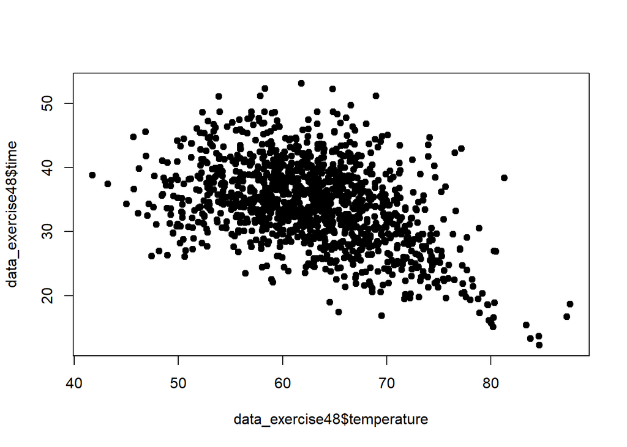

```r
plot(data_exercise48$temperature, data_exercise48$time, pch = 19)
```

In general, the data show a weak negative tendency, it means, if is high the delivery time so the temperature tends to be low.

5. Use methods of your choice to explore the relationship between temperature and driver, operator, number of ordered pizzas and bill. Is it clear which of the variables influence the pizza temperature?

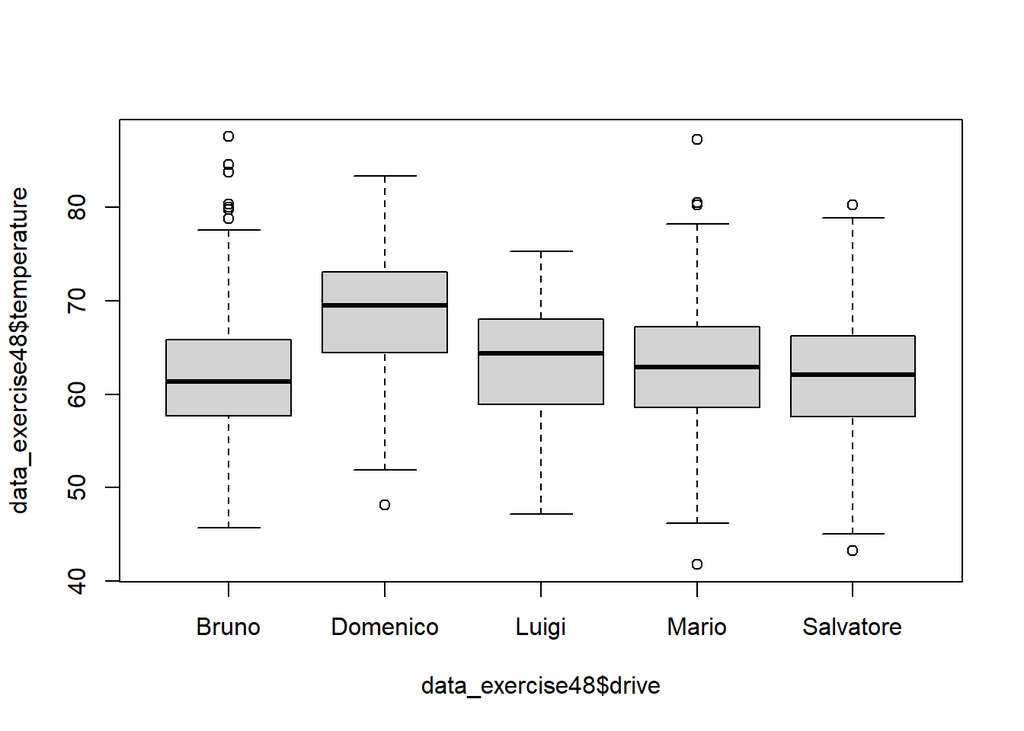

```r
boxplot(data_exercise48$temperature~data_exercise48$drive)
```

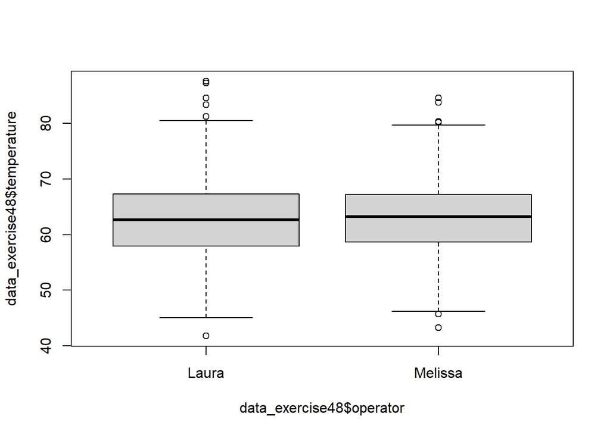

```r
boxplot(data_exercise48$temperature~data_exercise48$operator)
```

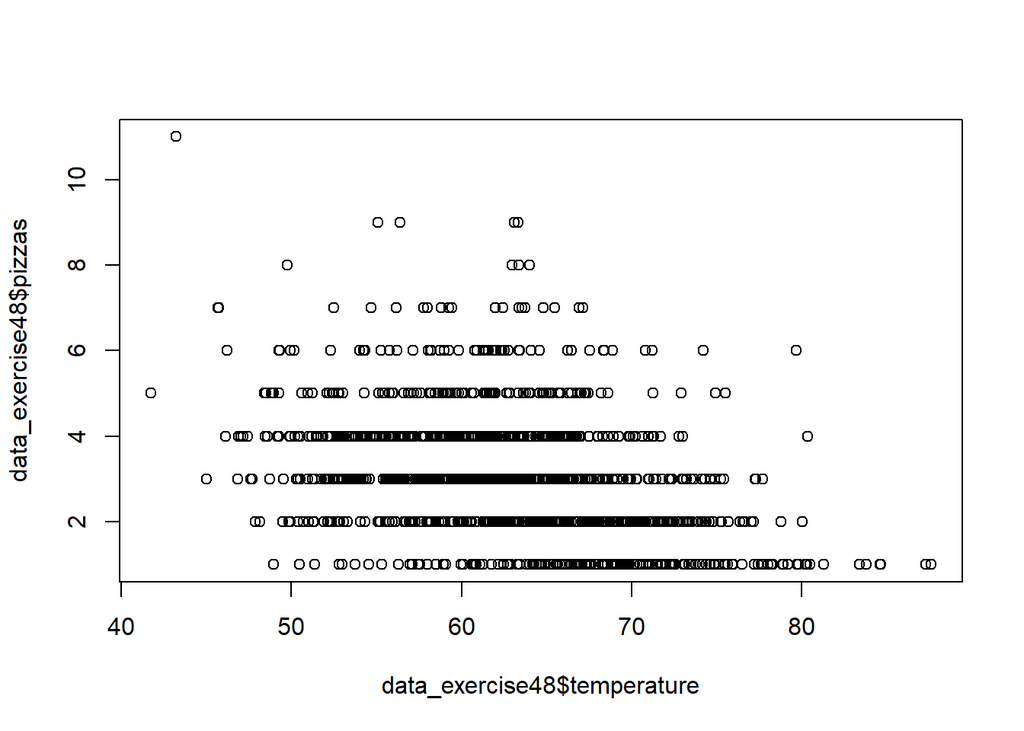

```r
plot(data_exercise48$temperature, data_exercise48$pizzas)
```

```r
cor(data_exercise48$temperature, data_exercise48$pizzas, method = "pearson")
```

```
## [1] -0.3685804
```

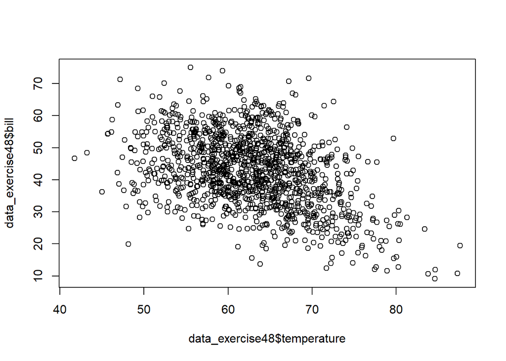

```r
plot(data_exercise48$temperature, data_exercise48$bill)
```

```r
cor(data_exercise48$temperature, data_exercise48$bill, method = "pearson")
```

```
## [1] -0.4151556
```